# Bank Churn Prediction

##### Model-2

Let's use dropout technique for the model to prevent overfitting. Use epochs 30.

```python
backend.clear_session()
np.random.seed(42)
import random
random.seed(42)
tf.random.set_seed(42)
```

```python
model2 = Sequential()
model2.add(Dense(64, activation = 'relu', input_dim = 12))
model2.add(Dropout(0.3))
model2.add(Dense(32, activation='relu'))
model2.add(Dropout(0.1))
model2.add(Dense(32, activation='relu'))
model2.add(Dense(1, activation = 'sigmoid'))
```

```python
model2.compile(optimizer=Adam(learning_rate=0.001), loss='binary_crossentropy', metrics=['accuracy'])
```

```python
history2=model2.fit(X_train, y_train,
          validation_split=0.2,
          epochs=30,
          batch_size=32,verbose=1)
```

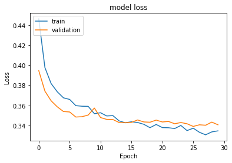

```python
plt.plot(history2.history['loss'])
plt.plot(history2.history['val_loss'])
plt.title('model loss')
plt.ylabel('Loss')
plt.xlabel('Epoch')
plt.legend(['train', 'validation'], loc='upper left')
plt.show()
```

It looks better the train and validation loss, let's check the recall score

```python
result = model2.evaluate(X_test, y_test)
```

```python
y_pred2=model2.predict(X_test)
```

```python
y_pred2 = (y_pred2 > 0.5)
y_pred2
```

```
array([[False],
       [False],
       [False],
       ...,
       [False],
       [False],
       [ True]])
```

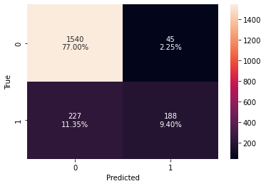

```python
cm = confusion_matrix(y_test, y_pred2)
labels = np.asarray(
        [
            ["{0:0.0f}".format(item) + "\n{0:.2%}".format(item / cm.flatten().sum())]
            for item in cm.flatten()
        ]
    ).reshape(2, 2)

plt.figure(figsize=(6, 4))
sns.heatmap(cm, annot=labels, fmt="")
plt.ylabel("True")
plt.xlabel("Predicted")
```

Let's tune the threshold using ROC-AUC for model2

```
Best Threshold=0.242737, G-Mean=0.788
```

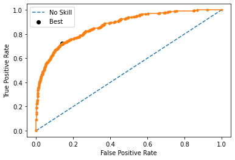

```python
yhat2 = model2.predict(X_test)
yhat2 = yhat2[:, 0]
fpr, tpr, thresholds2 = roc_curve(y_test, yhat2)
gmeans2 = np.sqrt(tpr * (1-fpr))
ix = np.argmax(gmeans2)
print('Best Threshold=%f, G-Mean=%.3f' % (thresholds2[ix], gmeans2[ix]))
pyplot.plot([0,1], [0,1], linestyle='--', label='No Skill')
pyplot.plot(fpr, tpr, marker='.')
pyplot.scatter(fpr[ix], tpr[ix], marker='o', color='black', label='Best')
pyplot.xlabel('False Positive Rate')
pyplot.ylabel('True Positive Rate')
pyplot.legend()
pyplot.show()
```

```python
y_pred_th2=model2.predict(X_test)
y_pred_th2 = (y_pred_th2 > thresholds2[ix])
y_pred_th2
```

```
array([[False],
       [False],
       [False],
       ...,
       [False],
       [False],
       [ True]])
```

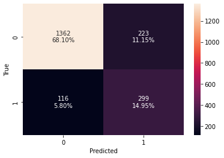

```python
cm = confusion_matrix(y_test, y_pred_th2)
labels = np.asarray(
        [
            ["{0:0.0f}".format(item) + "\n{0:.2%}".format(item / cm.flatten().sum())]
            for item in cm.flatten()
        ]
    ).reshape(2, 2)

plt.figure(figsize=(6, 4))
sns.heatmap(cm, annot=labels, fmt="")
plt.ylabel("True")
plt.xlabel("Predicted")
```

```python
print(classification_report(y_test,y_pred_th2))
```

```
              precision    recall  f1-score   support

           0       0.92      0.86      0.89      1585
           1       0.57      0.72      0.64       415

    accuracy                           0.83      2000
   macro avg       0.75      0.79      0.76      2000
weighted avg       0.85      0.83      0.84      2000
```

Recall score is 0.72, lets use Batch Normalization technique and check to see if we can increase the recall score.

##### Model-3

```python
backend.clear_session()
np.random.seed(42)
import random
random.seed(42)
tf.random.set_seed(42)
```

```python
model3 = Sequential()
model3.add(Dense(64, activation = 'relu', input_dim = 12))
model3.add(BatchNormalization())
model3.add(Dense(32, activation='relu'))
model3.add(Dense(32, activation='relu'))
model3.add(BatchNormalization())
model3.add(Dense(1, activation = 'sigmoid'))
```

```python
model3.compile(optimizer=Adam(learning_rate=0.001), loss='binary_crossentropy', metrics=['accuracy'])
```

```python
history3=model3.fit(X_train, y_train,
          validation_split=0.2,
          epochs=30,
          batch_size=32,verbose=1)
```

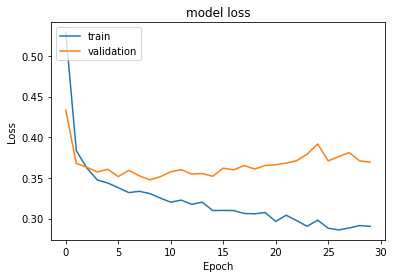

```python
plt.plot(history3.history['loss'])
plt.plot(history3.history['val_loss'])
plt.title('model loss')
plt.ylabel('Loss')
plt.xlabel('Epoch')
plt.legend(['train', 'validation'], loc='upper left')
plt.show()
```

```python
result = model3.evaluate(X_test, y_test)
```

```python
y_pred3=model3.predict(X_test)
y_pred3 = (y_pred3 > 0.5)
y_pred3
```

```
array([[False],
       [False],
       [False],
       ...,
       [False],
       [False],
       [False]])
```

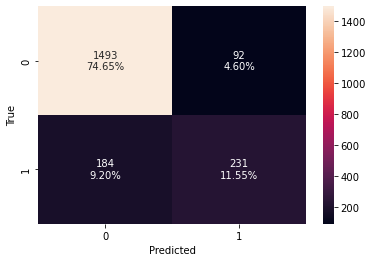

```python
cm = confusion_matrix(y_test, y_pred3)
labels = np.asarray(
        [
            ["{0:0.0f}".format(item) + "\n{0:.2%}".format(item / cm.flatten().sum())]
            for item in cm.flatten()
        ]
    ).reshape(2, 2)

plt.figure(figsize=(6, 4))
sns.heatmap(cm, annot=labels, fmt="")
plt.ylabel("True")
plt.xlabel("Predicted")
```

```python
print(classification_report(y_test,y_pred3))
```

```
              precision    recall  f1-score   support

           0       0.89      0.94      0.92      1585
           1       0.72      0.56      0.63       415

    accuracy                           0.86      2000
   macro avg       0.80      0.75      0.77      2000
weighted avg       0.85      0.86      0.86      2000
```

Let's tune the threshold using ROC-AUC for model3

```
Best Threshold=0.194015, G-Mean=0.790
```

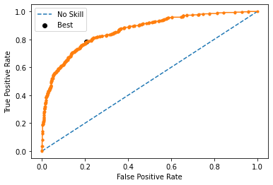

```python
yhat3 = model3.predict(X_test)
yhat3 = yhat3[:, 0]
fpr, tpr, thresholds3 = roc_curve(y_test, yhat3)
gmeans3 = np.sqrt(tpr * (1-fpr))
ix = np.argmax(gmeans3)
print('Best Threshold=%f, G-Mean=%.3f' % (thresholds3[ix], gmeans3[ix]))
pyplot.plot([0,1], [0,1], linestyle='--', label='No Skill')
pyplot.plot(fpr, tpr, marker='.')
pyplot.scatter(fpr[ix], tpr[ix], marker='o', color='black', label='Best')
pyplot.xlabel('False Positive Rate')
pyplot.ylabel('True Positive Rate')
pyplot.legend()
pyplot.show()
```

```python
y_pred_th3=model3.predict(X_test)
y_pred_th3 = (y_pred_th3 > thresholds3[ix])
y_pred_th3
```

```
array([[False],
       [ True],
       [False],
       ...,
       [False],
       [False],
       [ True]])
```

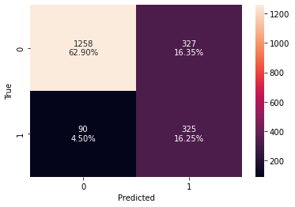

```python
cm = confusion_matrix(y_test, y_pred_th3)
labels = np.asarray(
        [
            ["{0:0.0f}".format(item) + "\n{0:.2%}".format(item / cm.flatten().sum())]
            for item in cm.flatten()
        ]
    ).reshape(2, 2)

plt.figure(figsize=(6, 4))
sns.heatmap(cm, annot=labels, fmt="")
plt.ylabel("True")
plt.xlabel("Predicted")
```

```python
print(classification_report(y_test,y_pred_th3))
```

```
              precision    recall  f1-score   support

           0       0.93      0.79      0.86      1585
           1       0.50      0.78      0.61       415

    accuracy                           0.79      2000
   macro avg       0.72      0.79      0.73      2000
weighted avg       0.84      0.79      0.81      2000
```

Recall score is 0.78, but the model is overfitting, so let's use Hyperparameter Optimization techniques including RandomizedSearchCV to increase the recall score of the model.

##### Model4 with Random Search CV

```python
backend.clear_session()
np.random.seed(42)
import random
random.seed(42)
tf.random.set_seed(42)
```

```python
def create_model4(lr,batch_size):
    model4 = Sequential()
    model4.add(Dense(64, activation = 'relu', input_dim = 12))
    model4.add(Dropout(0.3))
    model4.add(Dense(32, activation='relu'))
    model4.add(Dense(32, activation='relu'))
    model4.add(Dropout(0.1))
    model4.add(Dense(1, activation = 'sigmoid'))

    optimizer = tf.keras.optimizers.Adam(learning_rate=lr)
    model4.compile(optimizer = optimizer,loss = 'binary_crossentropy', metrics = ['accuracy'])
    return model4
```

```python
keras_estimator = KerasClassifier(build_fn=create_model4, verbose=1)
param_random = {
    'batch_size':[16, 32, 64, 128],
    "lr":[0.01,0.1,0.001],


}

kfold_splits = 5
random= RandomizedSearchCV(estimator=keras_estimator,
                    verbose=1,
                    cv=kfold_splits,
                    param_distributions=param_random,n_jobs=-1)
```

```python
random_result = random.fit(X_train, y_train,validation_split=0.2,verbose=1)
print("Best: %f using %s" % (random_result.best_score_, random_result.best_params_))
params = random_result.cv_results_['params']
```

```
Fitting 5 folds for each of 10 candidates, totalling 50 fits
Best: 0.843750 using {'lr': 0.01, 'batch_size': 16}
```

```python
estimator_m4=create_model4(batch_size=random_result.best_params_['batch_size'],lr=random_result.best_params_['lr'])

estimator_m4.summary()
```

```
Model: "sequential_1"
_________________________________________________________________
 Layer (type)                Output Shape              Param #
=================================================================
 dense_4 (Dense)             (None, 64)                832

 dropout_2 (Dropout)         (None, 64)                0

 dense_5 (Dense)             (None, 32)                2080

 dense_6 (Dense)             (None, 32)                1056

 dropout_3 (Dropout)         (None, 32)                0

 dense_7 (Dense)             (None, 1)                 33

=================================================================
Total params: 4,001
Trainable params: 4,001
Non-trainable params: 0
_________________________________________________________________
```

```python
optimizer = tf.keras.optimizers.Adam(random_result.best_params_['lr'])
estimator_m4.compile(loss='binary_crossentropy',optimizer=optimizer,metrics=['accuracy'])
history4=estimator_m4.fit(X_train, y_train, epochs=20, batch_size = 16, verbose=1,validation_split=0.2)
```

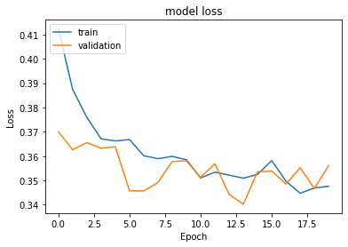

```python
plt.plot(history4.history['loss'])
plt.plot(history4.history['val_loss'])
plt.title('model loss')
plt.ylabel('Loss')
plt.xlabel('Epoch')
plt.legend(['train', 'validation'], loc='upper left')
plt.show()
```

```python
result = estimator_m4.evaluate(X_test, y_test)
```

```python
y_pred4=estimator_m4.predict(X_test)
y_pred4 = (y_pred4 > 0.5)
y_pred4
```

```
array([[False],
       [False],
       [False],
       ...,
       [False],
       [False],
       [False]])
```

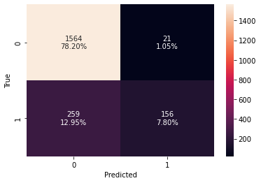

```python
cm = confusion_matrix(y_test, y_pred4)
labels = np.asarray(
        [
            ["{0:0.0f}".format(item) + "\n{0:.2%}".format(item / cm.flatten().sum())]
            for item in cm.flatten()
        ]
    ).reshape(2, 2)

plt.figure(figsize=(6, 4))
sns.heatmap(cm, annot=labels, fmt="")
plt.ylabel("True")
plt.xlabel("Predicted")
```

```
Best Threshold=0.127272, G-Mean=0.789
```

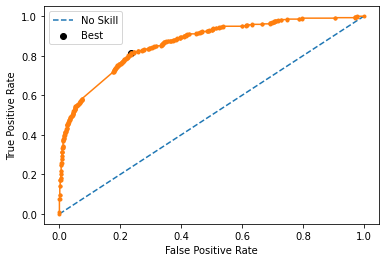

```python
yhat4 = estimator_m4.predict(X_test)
yhat4 = yhat4[:, 0]
fpr, tpr, thresholds4 = roc_curve(y_test, yhat4)
gmeans4 = np.sqrt(tpr * (1-fpr))
ix = np.argmax(gmeans4)
print('Best Threshold=%f, G-Mean=%.3f' % (thresholds4[ix], gmeans4[ix]))
pyplot.plot([0,1], [0,1], linestyle='--', label='No Skill')
pyplot.plot(fpr, tpr, marker='.')
pyplot.scatter(fpr[ix], tpr[ix], marker='o', color='black', label='Best')
pyplot.xlabel('False Positive Rate')
pyplot.ylabel('True Positive Rate')
pyplot.legend()
pyplot.show()
```

```python
y_pred_th4=estimator_m4.predict(X_test)
y_pred_th4 = (y_pred_th4 > thresholds4[ix])
y_pred_th4
```

```
array([[False],
       [False],
       [False],
       ...,
       [False],
       [False],
       [ True]])
```

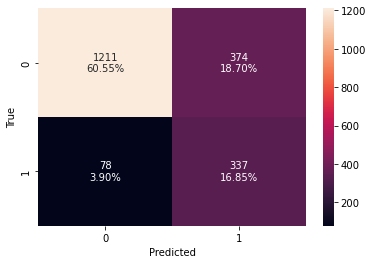

```python
cm = confusion_matrix(y_test, y_pred_th4)
labels = np.asarray(
        [
            ["{0:0.0f}".format(item) + "\n{0:.2%}".format(item / cm.flatten().sum())]
            for item in cm.flatten()
        ]
    ).reshape(2, 2)

plt.figure(figsize=(6, 4))
sns.heatmap(cm, annot=labels, fmt="")
plt.ylabel("True")
plt.xlabel("Predicted")
```

```python
print(classification_report(y_test,y_pred_th4))
```

```
              precision    recall  f1-score   support

           0       0.94      0.76      0.84      1585
           1       0.47      0.81      0.60       415

    accuracy                           0.77      2000
   macro avg       0.71      0.79      0.72      2000
weighted avg       0.84      0.77      0.79      2000
```

Recall score is 0.81, but there is noise in the model. The target variable is imbalance so apply SMOTE to balance this dataset and then apply hyperparamter tuning.

##### Model5 with SMOTE

```python
from imblearn.over_sampling import SMOTE
smote=SMOTE(sampling_strategy='not majority')
X_sm , y_sm = smote.fit_resample(X_train,y_train)
```

```python
backend.clear_session()
np.random.seed(42)
import random
random.seed(42)
tf.random.set_seed(42)
```

```python
model5 = Sequential()
model5.add(Dense(64, activation = 'relu', input_dim = 12))
model5.add(Dropout(0.3))
model5.add(Dense(32, activation='relu'))
model5.add(Dense(32, activation='relu'))
model5.add(Dropout(0.1))
model5.add(Dense(1, activation = 'sigmoid'))


model5.compile(optimizer = Adam(learning_rate=0.01),loss = 'binary_crossentropy', metrics = ['accuracy'])
history5=model5.fit(X_sm, y_sm,
          validation_split=0.2,
          epochs=50,
          batch_size=64,verbose=1)
```

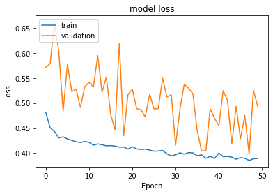

```python
plt.plot(history5.history['loss'])
plt.plot(history5.history['val_loss'])
plt.title('model loss')
plt.ylabel('Loss')
plt.xlabel('Epoch')
plt.legend(['train', 'validation'], loc='upper left')
plt.show()
```

```python
y_pred5=model5.predict(X_test)
y_pred5 = (y_pred5 > 0.5)
y_pred5
```

```
array([[False],
       [False],
       [False],
       ...,
       [False],
       [False],
       [ True]])
```

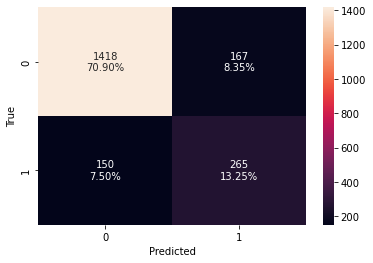

```python
cm = confusion_matrix(y_test, y_pred5)
labels = np.asarray(
        [
            ["{0:0.0f}".format(item) + "\n{0:.2%}".format(item / cm.flatten().sum())]
            for item in cm.flatten()
        ]
    ).reshape(2, 2)

plt.figure(figsize=(6, 4))
sns.heatmap(cm, annot=labels, fmt="")
plt.ylabel("True")
plt.xlabel("Predicted")
```

```python
print(classification_report(y_test,y_pred5))
```

```
              precision    recall  f1-score   support

           0       0.90      0.89      0.90      1585
           1       0.61      0.64      0.63       415

    accuracy                           0.84      2000
   macro avg       0.76      0.77      0.76      2000
weighted avg       0.84      0.84      0.84      2000
```

```
Best Threshold=0.372912, G-Mean=0.776
```

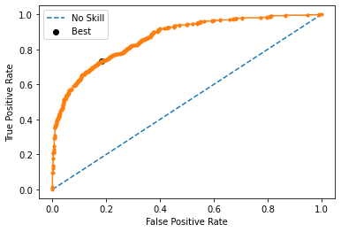

```python
yhat5 = model5.predict(X_test)
yhat5 = yhat5[:, 0]
fpr, tpr, thresholds5 = roc_curve(y_test, yhat5)
gmeans5 = np.sqrt(tpr * (1-fpr))
ix = np.argmax(gmeans5)
print('Best Threshold=%f, G-Mean=%.3f' % (thresholds5[ix], gmeans5[ix]))
pyplot.plot([0,1], [0,1], linestyle='--', label='No Skill')
pyplot.plot(fpr, tpr, marker='.')
pyplot.scatter(fpr[ix], tpr[ix], marker='o', color='black', label='Best')
pyplot.xlabel('False Positive Rate')
pyplot.ylabel('True Positive Rate')
pyplot.legend()
pyplot.show()
```

```python
y_pred_th5=model5.predict(X_test)
y_pred_th5= (y_pred_th5 > thresholds5[ix])
y_pred_th5
```

```
array([[False],
       [False],
       [False],
       ...,
       [False],
       [False],
       [ True]])
```

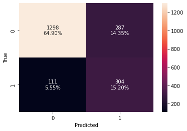

```python
cm = confusion_matrix(y_test, y_pred_th5)
labels = np.asarray(
        [
            ["{0:0.0f}".format(item) + "\n{0:.2%}".format(item / cm.flatten().sum())]
            for item in cm.flatten()
        ]
    ).reshape(2, 2)

plt.figure(figsize=(6, 4))
sns.heatmap(cm, annot=labels, fmt="")
plt.ylabel("True")
plt.xlabel("Predicted")
```

```python
print(classification_report(y_test,y_pred_th5))
```

```
              precision    recall  f1-score   support

           0       0.92      0.82      0.87      1585
           1       0.51      0.73      0.60       415

    accuracy                           0.80      2000
   macro avg       0.72      0.78      0.74      2000
weighted avg       0.84      0.80      0.81      2000
```

There is a lot of noise in the model, and the recall score is 0.73.

# Conclusion and key takeaways

Comparing the models' train and validation loss graphs shows that Model0 is better than the other models. For instance, Model1 with Adam and RMSprop is overfitting. Another example is Model5, that is used SMOTE data, has a lot of noise in the loss behavior. When we compare the recall scores, the models have better recall scores after the best threshold, mostly around 0.75. Model4 with Random Search CV has the highest recall score(0.81), but there is noise in the model. Therefore, we can select Model0 (recall=0.76) as a final model that is simple and has one hidden layer, and has smooth train and validation loss.